# Question

Quadratic functions are often expressed in [vertex form](https://en.wikipedia.org/wiki/Quadratic_function#Forms_of_a_univariate_quadratic_function):

$$y~=~a(x-h)^2+k$$

From the graph below, determine the values of the 3 parameters.

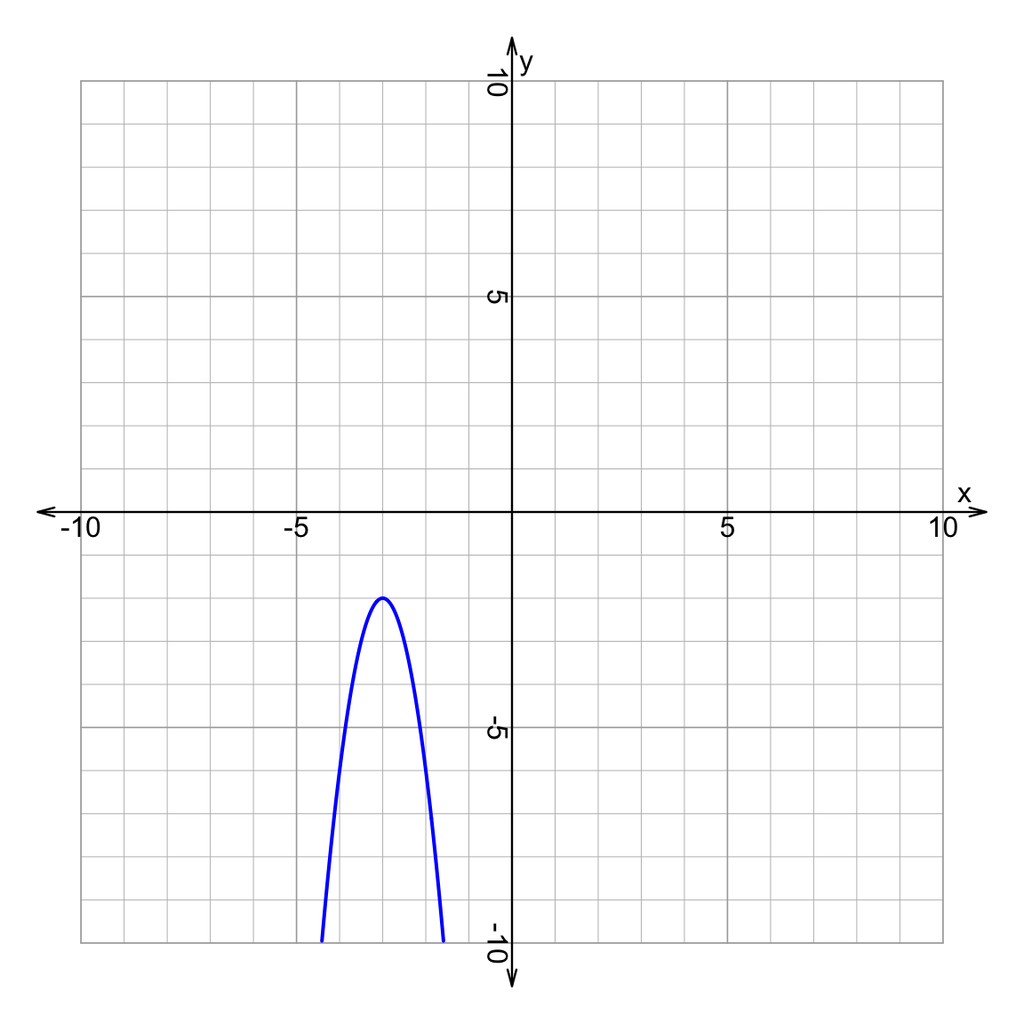

- $a=$ ##ANSWER1##
- $h=$ ##ANSWER2##
- $k=$ ##ANSWER3##

## Answerlist

- -7
- -6
- -5
- -4
- -3
- -2
- -1
- 0
- 1
- 2
- 3
- 4
- 5
- 6
- 7
- -7
- -6
- -5
- -4
- -3
- -2
- -1
- 0
- 1
- 2
- 3
- 4
- 5
- 6
- 7
- -7
- -6
- -5
- -4
- -3
- -2
- -1
- 0
- 1
- 2
- 3
- 4
- 5
- 6
- 7

# Solution

Based on function transformations, it should be clear that the vertex is at point $(h,k)$ and parameter $a$ dictates the vertical stretch and possible vertical reflection (which flips the parabola upside down, such that it looks like a hill, not a valley).

When determining $a$ from a graph, it is easiest to identify the point on the curve 1 unit to the right of the vertex. That point will be at $(h+1,k+a)$. By subtracting the $y$ value of the vertex from the $y$ value of that point 1 unit to the right, it is easy to find $a$.

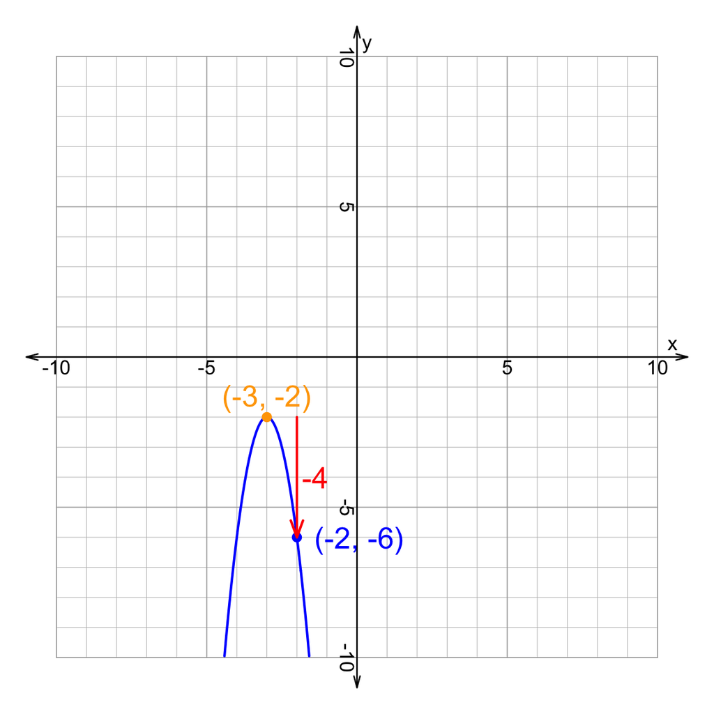

$$(-6)-(-2)~=~ -4$$

So,

- $a=-4$
- $h=-3$
- $k=-2$

Thus, the equation of the curve is:
$$y~=~-4(x+3)^2-2$$

# Meta-information

extype: cloze exclozetype: schoice|schoice|schoice exsolution: 000100000000000|000010000000000|000001000000000 exname: vertex_form_params_from_graph